# RegressionTrees_RandomForest_Boosting

San

2020/3/8

# Boston data set:

- Housing Values in Suburbs of Boston with 506 rows and 14 columns.

## Regression Trees

```r
rm(list = ls())
library(MASS)
library(tree)
set.seed(1)
train <- sample(1:nrow(Boston),  nrow(Boston)/2 )
tree.boston <- tree(medv ~ . ,Boston ,subset = train)
summary(tree.boston)
```

```
##
## Regression tree:
## tree(formula = medv ~ ., data = Boston, subset = train)
## Variables actually used in tree construction:
## [1] "rm"    "lstat" "crim"  "age"
## Number of terminal nodes:  7
## Residual mean deviance:  10.38 = 2555 / 246
## Distribution of residuals:
##     Min.  1st Qu.   Median     Mean  3rd Qu.     Max.
## -10.1800  -1.7770  -0.1775   0.0000   1.9230  16.5800
```

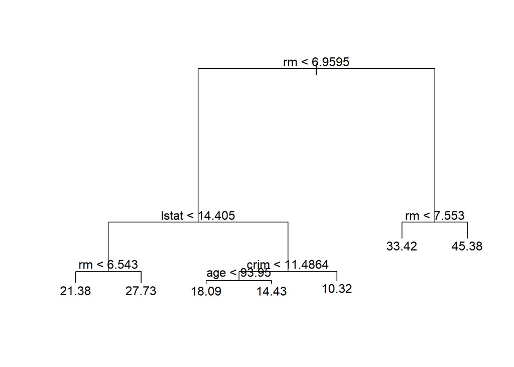

```r
plot(tree.boston)
text(tree.boston ,pretty =0)
```

- **lstat**: the percentage of individuals with **lower socioeconomic status**. > **lower** values of lstat correspond to **more expensive** houses.

```r
cv.boston <- cv.tree(tree.boston)
cv.boston
```

```
## $size
## [1] 7 6 5 4 3 2 1
##
## $dev
## [1]  4380.849  4544.815  5601.055  6171.917  6919.608 10419.472 19630.870
##
## $k
## [1]       -Inf   203.9641   637.2707   796.1207  1106.4931  3424.7810 10724.5951
##
## $method
## [1] "deviance"
##
## attr(,"class")
## [1] "prune"         "tree.sequence"
```

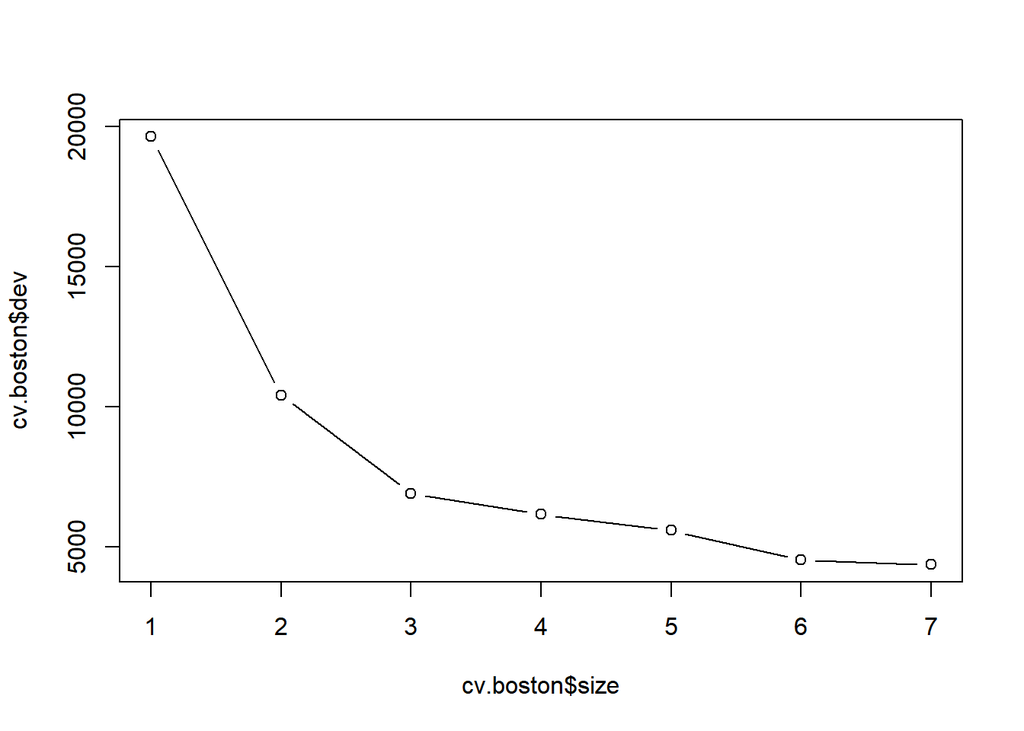

```r
plot(cv.boston$size ,cv.boston$dev ,type= 'b')
```

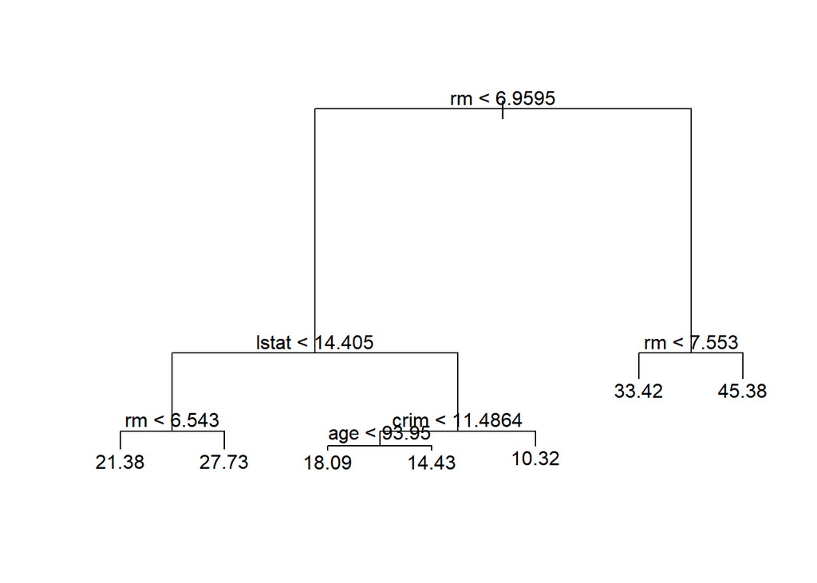

```r
prune.boston <- prune.tree(tree.boston ,best = 7)
plot(prune.boston)
text(prune.boston ,pretty =0)
```

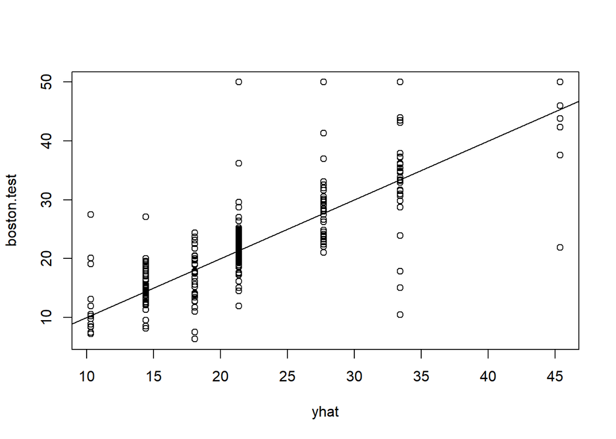

```r
yhat <- predict(tree.boston ,newdata = Boston[-train ,])
boston.test <- Boston[-train ,"medv"]
plot(yhat ,boston.test)
abline(0,1)
```

```r
mean((yhat - boston.test)^2)
```

```
## [1] 35.28688
```

- In other words, the **test set MSE** associated with the regression tree is **35.28**. The square **root of the MSE** is therefore around **5.94**, indicating that this model leads to test predictions that are **within around $6000** of the **true median home value** for the suburb.

## Bagging and Random Forests

```r
library(randomForest)
set.seed(1)
bag.boston <- randomForest(medv ~ . , data=Boston,
                         subset = train ,mtry = 13, importance =TRUE)
bag.boston
```

```
##
## Call:
##  randomForest(formula = medv ~ ., data = Boston, mtry = 13, importance = TRUE,      subset = train)
##                Type of random forest: regression
##                      Number of trees: 500
## No. of variables tried at each split: 13
##
##           Mean of squared residuals: 11.39601
##                     % Var explained: 85.17
```

- Note: **Bagging** is a **special** case of Random Forest with **m = p**. mtry=13 indicates that all 13 predictors should be considered.

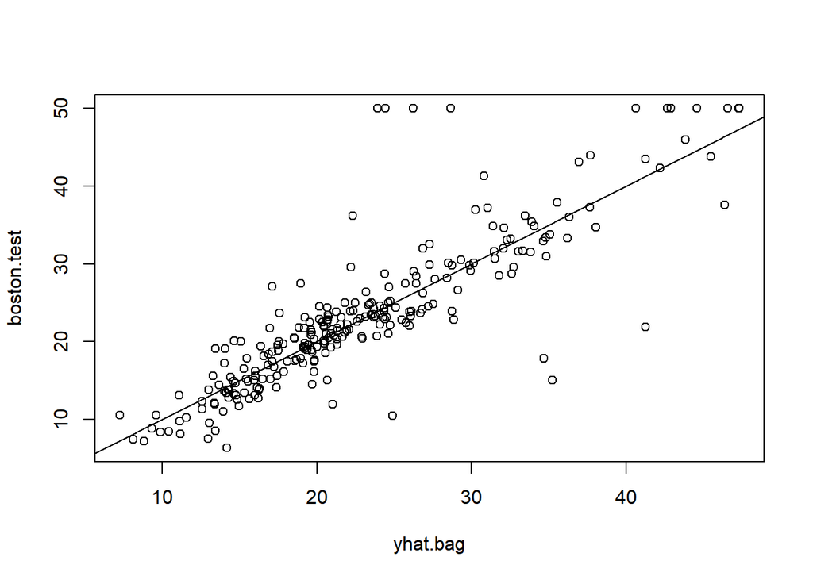

```r
yhat.bag <- predict(bag.boston ,newdata = Boston[-train ,])
plot(yhat.bag , boston.test)
abline (0,1)
```

```r
mean(( yhat.bag -boston.test)^2)
```

```
## [1] 23.59273
```

- The **test set MSE** associated with the bagged regression tree is **23.59**, almost **66.8%** of that obtained using an optimally-pruned **single tree** (Regression Tree with CV).

```r
bag.boston <- randomForest(medv~ . ,data = Boston ,subset = train,
                           mtry = 13, ntree = 10)
yhat.bag <- predict(bag.boston ,newdata = Boston[-train ,])
mean(( yhat.bag -boston.test)^2)
```

```
## [1] 24.87671
```

- **smaller number of tree** ($f_1,f_2,...,f_B$), can **not ensure** that every **input sampling data gets fitted** at least a few times.
- building a **random forest**:
  1. **p/3** variables in **regression** trees;
  2. **$\sqrt{p}$** variables in **classification** trees.

> Here use mtry = 6.

```r
set.seed(1)
rf.boston <- randomForest(medv~ . ,data = Boston ,subset =train ,
                          mtry = 6, importance =TRUE)
yhat.rf <- predict(rf.boston ,newdata = Boston[-train ,])
mean(( yhat.rf -boston.test)^2)
```

```
## [1] 19.62021
```

- The **test set MSE** is **19.62**; this indicates that random forests yielded an improvement over bagging in this case.

```r
importance(rf.boston)
```

```
##           %IncMSE IncNodePurity
## crim    16.697017    1076.08786
## zn       3.625784      88.35342
## indus    4.968621     609.53356
## chas     1.061432      52.21793
## nox     13.518179     709.87339
## rm      32.343305    7857.65451
## age     13.272498     612.21424
## dis      9.032477     714.94674
## rad      2.878434      95.80598
## tax      9.118801     364.92479
## ptratio  8.467062     823.93341
## black    7.579482     275.62272
## lstat   27.129817    6027.63740
```

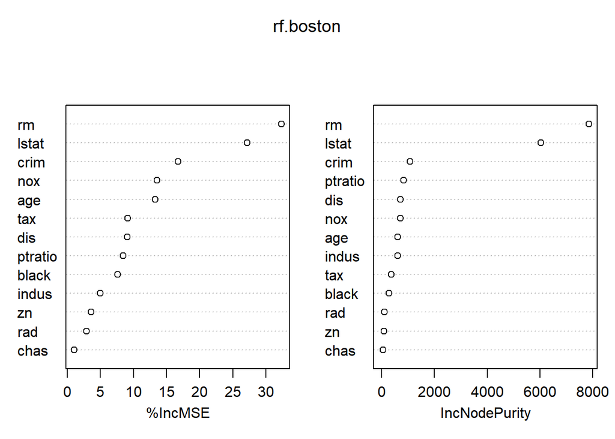

```r
varImpPlot(rf.boston)
```

- Two measures of **variable importance** are reported:
  1. the **mean decrease of accuracy** in predictions on the out of bag samples when a given **variable** is **excluded from the model**.
  2. the **total decrease in node impurity** that results from splits over that variable, averaged over all trees. For **regression** trees, the node **impurity** is measured by the **training RSS**, and for **classification** trees by the **deviance**.

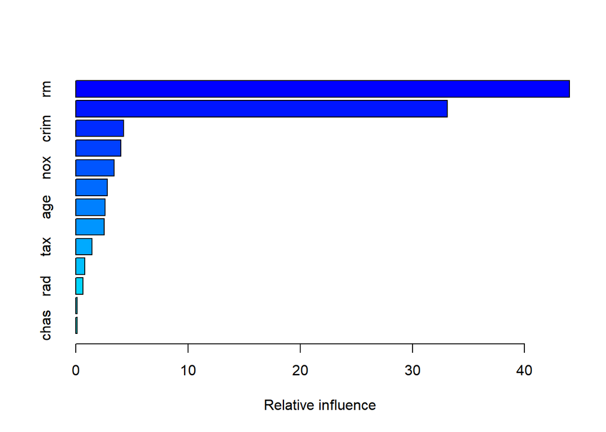

```
##             var    rel.inf
## rm           rm 43.9919329
## lstat     lstat 33.1216941
## crim       crim  4.2604167
## dis         dis  4.0111090
## nox         nox  3.4353017
## black     black  2.8267554
## age         age  2.6113938
## ptratio ptratio  2.5403035
## tax         tax  1.4565654
## indus     indus  0.8008740
## rad         rad  0.6546400
## zn           zn  0.1446149
## chas       chas  0.1443986
```

```r
library(gbm)
set.seed (1)
boost.boston <- gbm(medv ~ . ,data = Boston[train ,],
                    distribution = "gaussian",
                    n.trees = 5000,
                    interaction.depth = 4)
summary(boost.boston)
```

```r
yhat.boost <- predict(boost.boston ,newdata = Boston[-train ,],
                      n.trees = 5000)
mean(( yhat.boost -boston.test)^2)
```

```
## [1] 18.84709
```

- The **summary()** function produces a **relative influence plot** and also outputs the **relative influence statistics**.

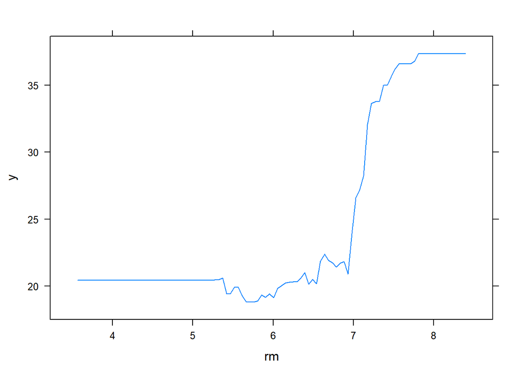

```r
par(mfrow =c(1,2))
plot(boost.boston ,i = "rm")
```

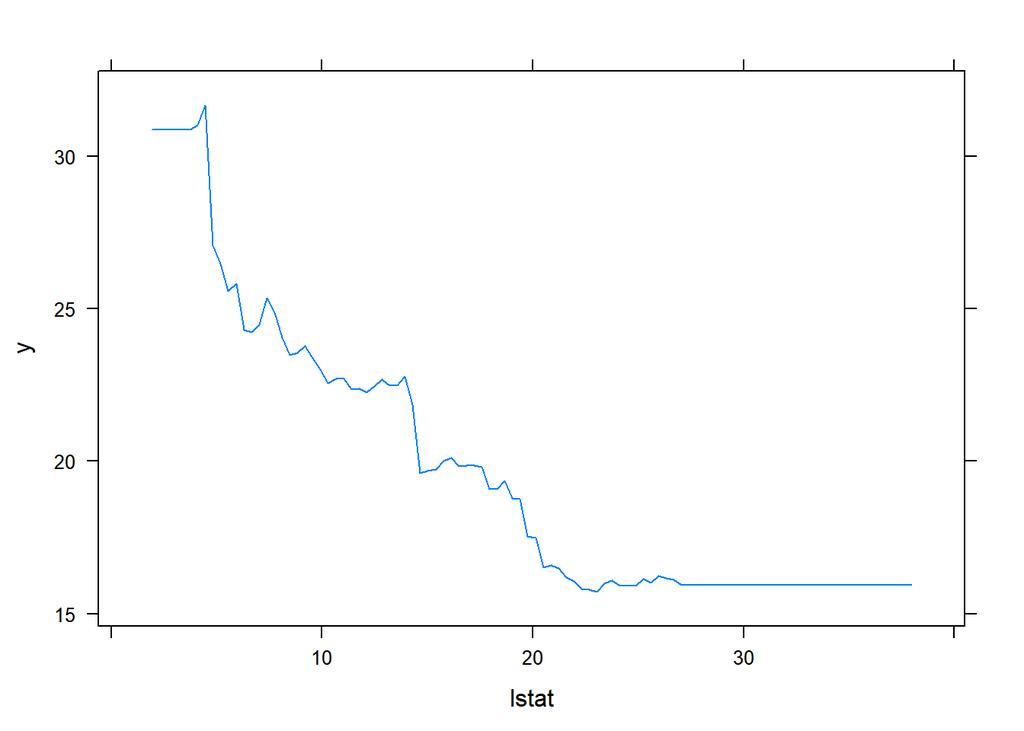

```r
plot(boost.boston ,i = "lstat")
```

- might expect: median **house prices** are **increasing with rm** and **decreasing with lstat**.

```r
boost.boston <- gbm(medv ~ . ,data = Boston[train ,],
                  distribution = "gaussian",
                  n.trees =5000 ,
                  interaction.depth =4,
                  shrinkage = 0.2,
                  verbose =F)
yhat.boost <- predict(boost.boston ,newdata = Boston[-train ,],
                   n.trees =5000)
mean(( yhat.boost -boston.test)^2)
```

```
## [1] 18.33455
```

- The **default $\lambda = 0.001$**, but this is easily modified. Here we take **$\lambda = 0.2$**.
- In this case, using λ = 0.2 leads to a slightly **lower test MSE** than λ = 0.001.